# Part II - ProsperLoan Dataset Exploration Report

## by Augustine Phiri

## Investigation Overview

> The project was focused much on answering the following questions:
- What factors affect a loan’s outcome status?
- What affects the borrower’s APR or interest rate?
- Are there differences between loans depending on how large the original loan amount was?

> So in summary, the factors that most seemed to affect a loan's outcome was the amount of money borrowed and the interest rate of the loan. The Higher the interest rate, and high loan values are likely to be past due. The employment statues had an enfluence of borrowers Apr. This was seen as the Employed individuals had the highest spread in the data, meaning that most of them were in current loan status. The higher the original loan amount the higher the loan appers to be.

> Despite that there is no much interesting difference between the categories of Loan Status and the borrower interest rate, charged off and defaulted loans are higher than the rest of loan status. looking at the correlation between loan status to the original loan amounts, it actually appears as though the larger the loan amount, the more chance of being in current loan status.

## Dataset Overview

> The Loan prosper dataset contained 113,937 loans with 81 variables on each loan. The dataset included loan amount, borrower rate (or interest rate), current loan status, borrower income, and many others. The main features of interest in my dataset and which I put much of my focus were the borrower's interest rate (BorrowerRate) and the current loan status (LoanStatus). The data was downloaded from [this link](https://docs.google.com/document/d/e/2PACX-1vQmkX4iOT6Rcrin42vslquX2_wQCjIa_hbwD0xmxrERPSOJYDtpNc_3wwK_p9_KpOsfA6QVyEHdxxq7/pub) which was provided in the classroom by Udacity.

> After analysis, the weak negative correlation between the `credit score` and the `borrower interest rate` was observed. The analysis indicated that as the `credit score increases` the `borrowers interest rate` decreases. This relationship was presented in a graph form for easy understanding.

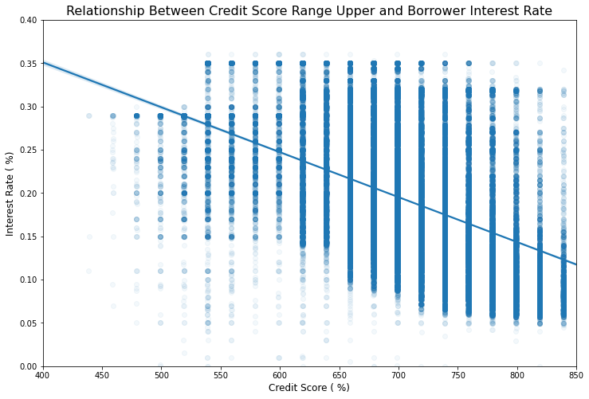

> In this analysis, it was observed that `Loan status` was affected by the `Employment Status`. `Employed`loan status showed highest frequency in current loan status comapared to the rest, and `full time` employment statues had higher frequency seconded by `Employed` in completed loan status. More loan is being taked by people how are employed.

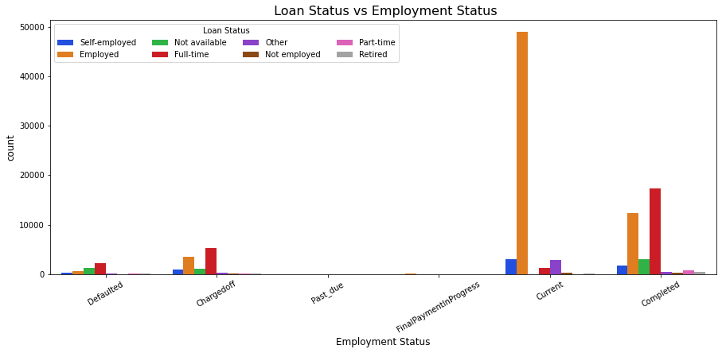

> The relationship among `Credit Score Range`, `Loan Original Amount` and Borrowers Rate was observed. The analysis indicated that as the `borrower's credit score` increases, the `` borrowers interest rate`` decreases (marking the negative correlation). Despit that it was not very serious, the ``Loan original amount` had effects on the interest rate. The higher the Loan original Amount, the lower was borrowers interest rate.

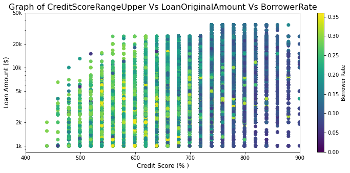